# Python Project (Prosper loan)

Python Project - (Dataset Exploration Title) by (Yusuff Alao)

## Introduction

This project is about a loan comapny known as Prosper Loan. I will be conducting some exploratory and explanatory analysis on the dataset. This dataset will be imported into the notebook using the pandas library. Other libraries that will be used include;matplotlib, seaborn and numpy.

## Preliminary Wrangling

```python
import numpy as np
import pandas as pd
import matplotlib.pyplot as plt
import seaborn as sns
```

```python
df=pd.read_csv('Prosper Loan.csv')
```

```python
df
```

|  | ListingKey | ListingNumber | ListingCreationDate | CreditGrade | Term | LoanStatus | ClosedDate | BorrowerAPR | BorrowerRate | LenderYield | ... | LP_ServiceFees | LP_CollectionFees | LP_GrossPrincipalLoss | LP_NetPrincipalLoss | LP_NonPrincipalRecoverypayments | PercentFunded | Recommendations | InvestmentFromFriendsCount | InvestmentFromFriendsAmount | Investors |
| --- | --- | --- | --- | --- | --- | --- | --- | --- | --- | --- | --- | --- | --- | --- | --- | --- | --- | --- | --- | --- | --- |
| 0 | 1021339766868145413AB3B | 193129 | 09:29.3 | C | 36 | Completed | 14/08/2009 00:00 | 0.16516 | 0.1580 | 0.1380 | ... | -133.18 | 0.0 | 0.0 | 0.0 | 0.0 | 1.0 | 0 | 0 | 0.0 | 258 |
| 1 | 10273602499503308B223C1 | 1209647 | 28:07.9 | NaN | 36 | Current | NaN | 0.12016 | 0.0920 | 0.0820 | ... | 0.00 | 0.0 | 0.0 | 0.0 | 0.0 | 1.0 | 0 | 0 | 0.0 | 1 |
| 2 | 0EE9337825851032864889A | 81716 | 00:47.1 | HR | 36 | Completed | 17/12/2009 00:00 | 0.28269 | 0.2750 | 0.2400 | ... | -24.20 | 0.0 | 0.0 | 0.0 | 0.0 | 1.0 | 0 | 0 | 0.0 | 41 |
| 3 | 0EF5356002482715299901A | 658116 | 02:35.0 | NaN | 36 | Current | NaN | 0.12528 | 0.0974 | 0.0874 | ... | -108.01 | 0.0 | 0.0 | 0.0 | 0.0 | 1.0 | 0 | 0 | 0.0 | 158 |
| 4 | 0F023589499656230C5E3E2 | 909464 | 38:39.1 | NaN | 36 | Current | NaN | 0.24614 | 0.2085 | 0.1985 | ... | -60.27 | 0.0 | 0.0 | 0.0 | 0.0 | 1.0 | 0 | 0 | 0.0 | 20 |
| ... | ... | ... | ... | ... | ... | ... | ... | ... | ... | ... | ... | ... | ... | ... | ... | ... | ... | ... | ... | ... | ... |
| 113932 | E6D9357655724827169606C | 753087 | 55:02.7 | NaN | 36 | Current | NaN | 0.22354 | 0.1864 | 0.1764 | ... | -75.58 | 0.0 | 0.0 | 0.0 | 0.0 | 1.0 | 0 | 0 | 0.0 | 1 |
| 113933 | E6DB353036033497292EE43 | 537216 | 42:55.3 | NaN | 36 | FinalPaymentInProgress | NaN | 0.13220 | 0.1110 | 0.1010 | ... | -30.05 | 0.0 | 0.0 | 0.0 | 0.0 | 1.0 | 0 | 0 | 0.0 | 22 |
| 113934 | E6E13596170052029692BB1 | 1069178 | 49:12.7 | NaN | 60 | Current | NaN | 0.23984 | 0.2150 | 0.2050 | ... | -16.91 | 0.0 | 0.0 | 0.0 | 0.0 | 1.0 | 0 | 0 | 0.0 | 119 |
| 113935 | E6EB3531504622671970D9E | 539056 | 18:26.6 | NaN | 60 | Completed | 13/08/2013 00:00 | 0.28408 | 0.2605 | 0.2505 | ... | -235.05 | 0.0 | 0.0 | 0.0 | 0.0 | 1.0 | 0 | 0 | 0.0 | 274 |
| 113936 | E6ED3600409833199F711B7 | 1140093 | 27:37.7 | NaN | 36 | Current | NaN | 0.13189 | 0.1039 | 0.0939 | ... | -1.70 | 0.0 | 0.0 | 0.0 | 0.0 | 1.0 | 0 | 0 | 0.0 | 1 |

113937 rows × 81 columns

```python
df.info()
```

```
<class 'pandas.core.frame.DataFrame'>
RangeIndex: 113937 entries, 0 to 113936
Data columns (total 81 columns):
 #   Column                               Non-Null Count   Dtype
---  ------                               --------------   -----
 0   ListingKey                           113937 non-null  object
 1   ListingNumber                        113937 non-null  int64
 2   ListingCreationDate                  113937 non-null  object
 3   CreditGrade                          28953 non-null   object
 4   Term                                 113937 non-null  int64
 5   LoanStatus                           113937 non-null  object
 6   ClosedDate                           55089 non-null   object
 7   BorrowerAPR                          113912 non-null  float64
 8   BorrowerRate                         113937 non-null  float64
 9   LenderYield                          113937 non-null  float64
```

[output cut: 73 more lines]

### What is the structure of your dataset?

This dataset contains 113937 rows and 81 columns. It contains different datatypes which include;boolean, floats,integer,and objects.

### What is/are the main feature(s) of interest in your dataset?

Some of the features include; Customer demographics, Loan interest, Investors

### What features in the dataset do you think will help support your investigation into your feature(s) of interest?

Features that will help with the area of interest; Employment status, Income range, Employment status duration, credit score range, occupation, loan status, Interest rate, Investors, Borrower state

## Univariate Exploration

Univariate Chart Employment Status, Occupation, Borrower State, Term, Loan Status,Current Credit Lines.

```python
df.EmploymentStatus.value_counts()
```

```
Employed         67322
Full-time        26355
Self-employed     6134
Not available     5347
Other             3806
Part-time         1088
Not employed       835
Retired            795
Name: EmploymentStatus, dtype: int64
```

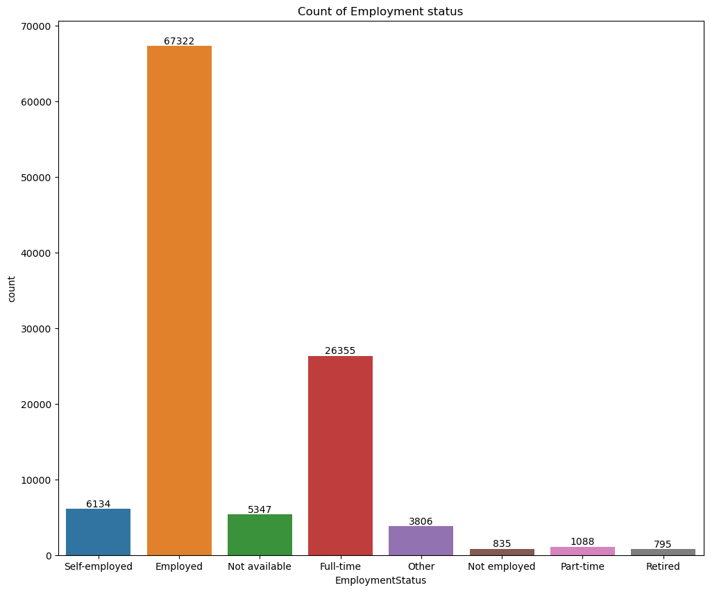

```python
plt.figure(figsize=(12,10))
ax = sns.countplot(data=df,x='EmploymentStatus')
ax.bar_label(ax.containers[0])
plt.title('Count of Employment status');
```

```python
df.BorrowerState.value_counts()
```

```
CA    14717
TX     6842
NY     6729
FL     6720
IL     5921
GA     5008
OH     4197
MI     3593
VA     3278
NJ     3097
NC     3084
WA     3048
PA     2972
MD     2821
MO     2615
MN     2318
MA     2242
CO     2210
IN     2078
AZ     1901
WI     1842
OR     1817
TN     1737
AL     1679
CT     1627
SC     1122
NV     1090
KS     1062
KY      983
OK      971
LA      954
UT      877
AR      855
MS      787
NE      674
ID      599
NH      551
NM      472
RI      435
HI      409
WV      391
DC      382
MT      330
DE      300
VT      207
AK      200
SD      189
IA      186
WY      150
ME      101
ND       52
Name: BorrowerState, dtype: int64
```

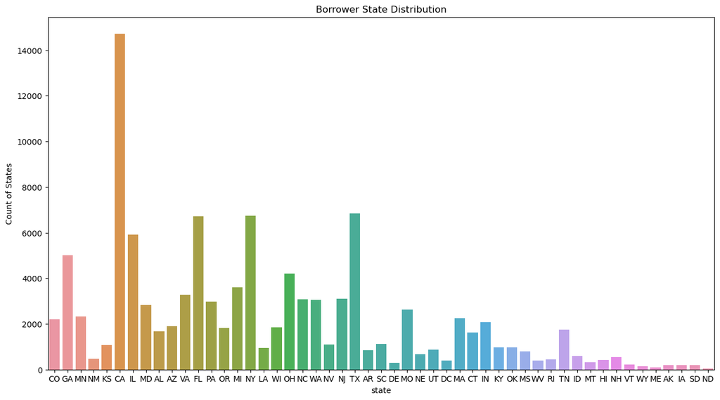

```python
plt.figure(figsize=(15,8))
sns.countplot(data=df,x='BorrowerState')
plt.title('Borrower State Distribution')
plt.xlabel('state')
plt.ylabel('Count of States');
```

```python
df.LoanStatus.value_counts()
```

```
Current                   56576
Completed                 38074
Chargedoff                11992
Defaulted                  5018
Past Due (1-15 days)        806
Past Due (31-60 days)       363
Past Due (61-90 days)       313
Past Due (91-120 days)      304
Past Due (16-30 days)       265
FinalPaymentInProgress      205
Past Due (>120 days)         16
Cancelled                     5
Name: LoanStatus, dtype: int64
```

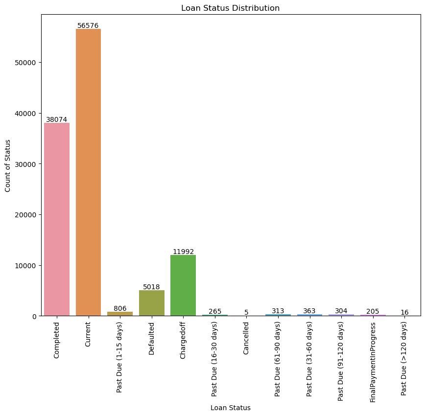

```python
plt.figure(figsize=(10,8))
ax=sns.countplot(data=df,x='LoanStatus')
ax.bar_label(ax.containers[0])
plt.xticks(rotation=90)
plt.title('Loan Status Distribution')
plt.xlabel('Loan Status')
plt.ylabel('Count of Status');
```

```python
df.Term.value_counts()
```

```
36    87778
60    24545
12     1614
Name: Term, dtype: int64
```

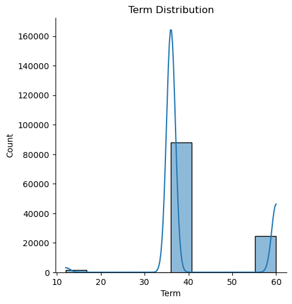

```python
sns.displot(df.Term,bins=10,kde=True)
plt.title('Term Distribution');
```

```python
df.Occupation.value_counts()
```

```
Other                          28617
Professional                   13628
Computer Programmer             4478
Executive                       4311
Teacher                         3759
                               ...
Dentist                           68
Student - College Freshman        41
Student - Community College       28
Judge                             22
Student - Technical School        16
Name: Occupation, Length: 67, dtype: int64
```

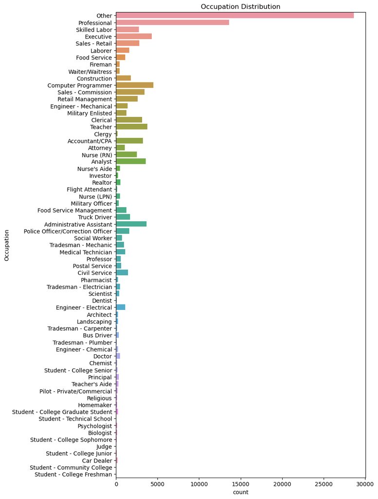

```python
plt.figure(figsize=(8,15))
sns.countplot(data=df, y='Occupation')
plt.title('Occupation Distribution');
```

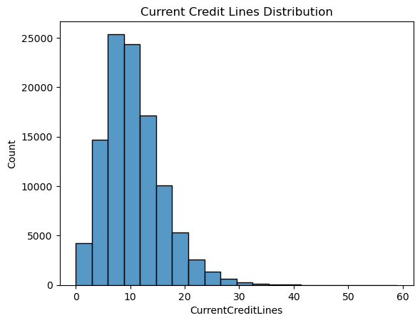

```python
sns.histplot(data=df,x='CurrentCreditLines',bins=20)
plt.title('Current Credit Lines Distribution');
```

## Bivariate Exploration

> In this section, investigate relationships between pairs of variables in your data. Make sure the variables that you cover here have been introduced in some fashion in the previous section (univariate exploration).

## Bivariate Charts

BorrowerAPR vs IncomeRange Employment Status vs BorrowerAPR Loan Status vs Borrower APR

[figure not shown]

```python
sns.catplot(
    data=df, y="BorrowerAPR", x="IncomeRange", kind="bar")
plt.xticks(rotation=90)
plt.title('BorrowerAPR vs IncomeRange');
```

```python
df['IncomeRange'] = df['IncomeRange'].replace(['Not displayed','Not employed'], ['$0','$0']);
```

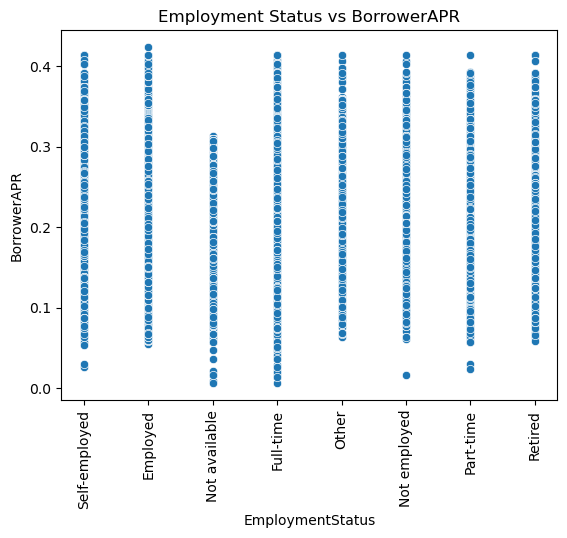

```python
sns.scatterplot(data=df,x='EmploymentStatus',y='BorrowerAPR')
plt.xticks(rotation=90)
plt.title('Employment Status vs BorrowerAPR');
```

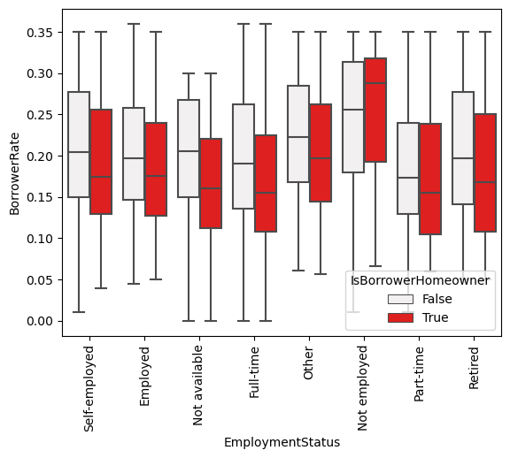

```python
sns.boxplot(data=df,x='EmploymentStatus',y='BorrowerRate',color='red',hue='IsBorrowerHomeowner')
plt.xticks(rotation=90);
```

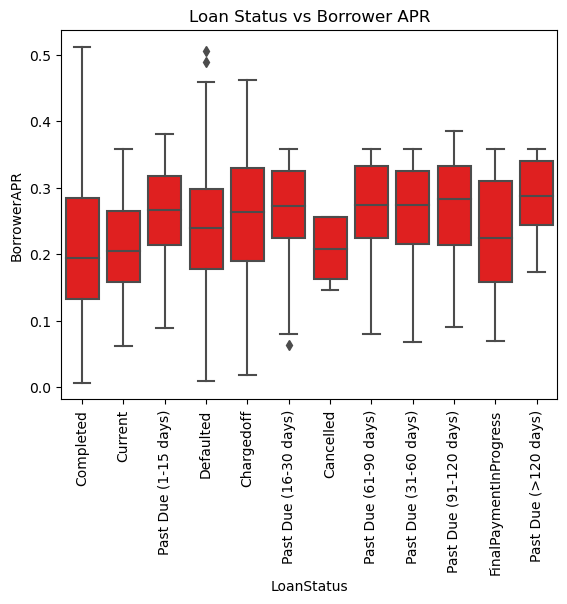

```python
sns.boxplot(data=df,x='LoanStatus',y='BorrowerAPR',color='red')
plt.xticks(rotation=90)
plt.title('Loan Status vs Borrower APR');
```

### Talk about some of the relationships you observed in this part of the investigation. How did the feature(s) of interest vary with other features in the dataset?

I checked the relationship between the employment status and borrower rate to see how the employment status affect the loan rate.

### Did you observe any interesting relationships between the other features (not the main feature(s) of interest)?

I observed that the higher the income range, the lower the APR. The relationship between the loan status and borrower APR showed that borrowers with low APR have completed their loan payment. Further analysis into the employment status would give more insights.

## Conclusions

The APR of borrowers with $0 need to be reviewed to prevent long term payment of the loan or inability to repay the loan.

The observations shows the correlation between the features of the dataset and how they affect the loan outcome, the laon term and even the inetrest rate. Further exploration into the dataset would give a more indepth result.